# Growth in Diagnostic Testing and Its Impact on Emergency Departments

January 2025

Authors

Affiliation

Steven Wyatt

The Strategy Unit

Andrew Jones

# Executive Summary

In this report, we examine rates of diagnostic testing in Emergency Departments (EDs) in England. We investigate how rates of testing have changed in recent years, and we explore how these changes have influenced both patient journeys through the ED and the likelihood of admission to hospital.

This analysis relied on the Emergency Care Data Set (ECDS) and its predecessor. The quality of these datasets is variable and changing. We therefore based the study on a subset of providers whose data submissions were sufficiently complete and consistent. The results obtained from this subset of providers - who were broadly representative of EDs in England – both approximate the changes seen in England as a whole and allow us to draw conclusions with more confidence. We find that:

#### Testing rates in EDs continue to grow, but have slowed in recent years

Between 2012/13 and 2023/24, the average number of tests per attendance - the testing rate - doubled. Growth was more rapid in the earlier part of this period, and has slowed since 2018/19.

Testing rates for patients who were later admitted were higher than for patients who were not admitted. However, g*rowth* in testing rates was higher for patients who were not admitted.

Growth was not evenly distributed across test types. In the four years between 2019/20 and 2023/24, the testing rate for three high-volume tests grew by more than 40%. These tests were: C-reactive protein measurement, CT scan, and bone profile. Several low-volume tests, including lipid panels, MRI scans, and serologic tests, grew at more than twice the rate of attendances.

#### Growth in testing in EDs cannot be explained by changes in casemix

The increase in tests per attendance cannot be explained by changes in patient casemix. Having adjusted for casemix, we found that the odds of a patient receiving a test increased for most test types between 2019/20 and 2023/24. This result echoes the findings of an earlier analysis, which examined the same issue over the period from 2012/13 to 2019/20. In light of this earlier work, we see that for some tests - notably CT and MRI scans - the casemix-adjusted growth rates appear to have slowed since 2019/20.

In another report, we found that the increasing testing rates in ED between 2010/11 and 2015/16 were, in part, due to the growing complexity of the casemix. By contrast, casemix did not change substantially from 2019/20 to 2023/24. This negligible change in casemix, along with a slowing of casemix-adjusted growth rates for some tests, might explain why the growth in the number of tests per attendance has slowed in recent years.

#### **Most tests were associated with a longer stay in the ED**

We found that most tests were associated with longer patient stays in the ED. We suggest two potential causal explanations, though these act in opposite directions.

The first explanation is perhaps the most intuitive: it takes time to order and conduct tests, and to incorporate results into a patient’s treatment plan. From this perspective, we might see tests as adding time to a patient’s ED stay. Another explanation is that longer ED stays may lead to more testing within the ED. This might arise, for example, when there are insufficient beds to enable prompt admission when required. Indeed, there may be truth in both explanations. However, we cannot distinguish between causal theories on the basis of this analysis, and we therefore state associations only.

The association between tests and duration in the ED was particularly marked for imaging tests. The presence of CT scans, ultrasounds, and plain radiography as part of a patient’s ED care, were associated with an additional hour in the ED, on average. MRI scans were associated with an additional three hours.

It should be noted that five tests were associated with somewhat *shorter* stays in the ED. This finding might indicate that these tests provided information that allowed clinicians to expedite a patient’s journey through the ED.

Of the tests that were associated with *longer* stays in the ED, five occurred with sufficiently high frequency to have a material impact on an ED’s waiting times: CT scans; plain radiography; urea and electrolytes; complete blood count; and C-reactive protein measurement. Two of these tests, CT scan and C-reactive protein measurement, have increased in volume rapidly since 2019/20.

#### The relationship between the number of tests carried out and the time a patient spends in the ED has changed

The number of patients who receive many tests has increased, which has consequences for ED waiting times. In 2019/20, the additional time associated with a patient’s stay for each test beyond the fifth was minimal. By 2023/24, each of these additional tests was, on average, associated with a further 30+ minutes in the ED. Whilst this finding is clear in the data, it is not easy to explain. Potential lines of enquiry might focus on the extent of asynchronous testing, or on re-testing for those whose care is delayed.

#### Increased testing rates in EDs may mean that fewer patients are admitted

We have already seen that the casemix-adjusted odds of receiving most tests have increased in recent years. But we also found that, for many tests, including most of the high-volume tests, the casemix-adjusted *odds of admission having received the test* have fallen. A similar pattern was observed in an earlier report, which examined the issue for the years 2010/11 to 2015/16.

These results might indicate that increased testing in EDs enables clinicians to rule out diagnoses that might otherwise lead to an admission. It is unclear, however, if clinical practice in EDs is leading this change, or if practice is responding to constraints in the operational context and, in particular, to the reduced availability of beds.

# Introduction

Over the last decade, growth in diagnostic testing in emergency departments (EDs) has been rapid. Earlier analysis conducted by the Strategy Unit ([2019](https://www.strategyunitwm.nhs.uk/publications/waiting-times-and-attendance-durations-english-ae-departments), [2023](https://www.strategyunitwm.nhs.uk/sites/default/files/2023-05/MDSN%20Diagnostic_growth_report%20Apr2023.pdf)) suggests that this growth may have implications for the timeliness of patient care, for decisions on whether to admit a patient, and for crowding in EDs.

For the sake of readability, we use the term, “test”, to refer to a unit of diagnostic activity. We acknowledge that some of these “tests” might also be therapeutic procedures.

This is the first of two reports that will examine the impact of the growth in diagnostic testing on urgent and emergency care services. Here, we update and expand our previous analyses to assess the extent to which the trends identified in earlier reports have continued. We explore growth in diagnostic testing in EDs in England, and consider the implications of this growth. We sought to answer four questions:

**Questions on diagnostic testing in EDs that we address in this report:**

1. How has the number of tests per attendance changed over time?
2. To what extent can changes in ED patient casemix explain the growth in test rates?
3. What are the implications of this growth for the timeliness of care in ED?
4. What are the implications of this growth for decisions to admit?

We start by describing our analytical approach, before addressing each question in turn. Detailed information about the methods and limitations are provided for each analysis.

# Analytical Approach

The analyses we present here investigate the consequences of increased diagnostic testing within major emergency (Type 1) departments. To address the questions above, we relied on SUS A&E and EC data sets. Whilst these are high-quality, patient-level sources, we observed considerable variation in recording practices, both across the population of provider trusts and over time. If overlooked, this variation would adversely affect both the reliability and validity of our results.

### The use of provider sampling

To increase the chances that our findings would be reliable and valid for a given question, we conducted each analysis on data from a sample of providers. These provider samples were non-random: we included a provider in a sample if the quality of their data submissions met our requirements for the given question.

We were able to identify two distinct samples that met our needs for the four questions. The first sample (Sample 1), of 28 providers, was used to address Question 1. A second sample (Sample 2), of 16 providers, was used in the analyses relating to Questions 2 to 4.

Whilst sampling should improve the reliability and validity of our results, we can only make general statements about the effect of testing on EDs if our sample of providers is *representative* of the population of providers. That is to say, the providers in our sample(s) and population should have similar characteristics.

There is a trade-off to be made here. The larger our sample of providers, the more likely it is to be representative of the population of providers. But the larger we make our sample, the more we compromise on data quality, which will likely to decrease the reliability of our results.

Details of the sampling methods, our approach to the trade-off, and the measures of representation can be found in Section 7.

### Excluded attendances

For providers within our samples, the analyses cover all unplanned attendances of persons with an English postcode, with some exceptions. We excluded cases were a person left the ED before being treated, and persons streamed to other care services. In addition, we excluded cases where the patient died during an attendance and those where the patient was found to be dead on arrival at the ED.

### Question-specific approaches

Details of our approach to each distinct question can be found in the expandable “Method and Limitations” boxes, in the corresponding subsections of the Analysis section, below.

### Reproducibility

The computer code used to perform this analysis can be found a [GitHub repository](https://github.com/The-Strategy-Unit/diagnostic_growth_uec) (permissions currently required).

# Analysis

### Characteristics of patients in the study

As detailed above, the analyses in this report rely on two data samples. Analysis A1 is based on Sample 1, while all other analyses use Sample 2. Selected characteristics of patients in Sample 2 are shown in Table 1. Information on Sample 1 (and further information on Sample 2) can be found in Section 7.

Table 1: A summary of selected characteristics of the patients in Sample 2

|  |  | attendances (%) 2019/20 | attendances (%) 2023/24 |
| --- | --- | --- | --- |
| total | - | 1,491,703 (100.0%) | 1,836,831 (100.0%) |
| age group | 00-09 | 220,342 (14.8%) | 281,013 (15.3%) |
|  | 10-19 | 150,174 (10.1%) | 191,709 (10.4%) |
|  | 20-29 | 187,577 (12.6%) | 198,332 (10.8%) |
|  | 30-39 | 159,863 (10.7%) | 199,022 (10.8%) |
|  | 40-49 | 135,925 (9.1%) | 167,130 (9.1%) |
|  | 50-59 | 152,665 (10.2%) | 184,733 (10.1%) |
|  | 60-69 | 133,293 (8.9%) | 177,847 (9.7%) |
|  | 70-79 | 158,251 (10.6%) | 199,874 (10.9%) |
|  | 80-89 | 144,244 (9.7%) | 179,237 (9.8%) |
|  | 90+ | 49,304 (3.3%) | 57,890 (3.2%) |
|  | Not known | 65 (0.0%) | 44 (0.0%) |
| sex | Female | 760,337 (51.0%) | 941,520 (51.3%) |
|  | Male | 731,366 (49.0%) | 895,311 (48.7%) |
| chief complaint | Airway / breathing | 135,622 (9.1%) | 170,897 (9.3%) |
|  | Circulation / chest | 167,354 (11.2%) | 214,296 (11.7%) |
|  | Environmental | 14,011 (0.9%) | 13,136 (0.7%) |
|  | Eye | 19,544 (1.3%) | 24,825 (1.4%) |
|  | Gastrointestinal | 172,407 (11.6%) | 210,535 (11.5%) |
|  | General / minor / admin | 138,741 (9.3%) | 193,367 (10.5%) |
|  | Genitourinary | 44,489 (3.0%) | 56,039 (3.1%) |
|  | Head and neck | 54,014 (3.6%) | 81,128 (4.4%) |
|  | Neurological | 134,893 (9.0%) | 143,158 (7.8%) |
|  | ObGyn | 18,218 (1.2%) | 21,061 (1.1%) |
|  | Psychosocial / Behaviour change | 47,691 (3.2%) | 35,884 (2.0%) |
|  | Skin | 88,133 (5.9%) | 100,783 (5.5%) |
|  | Trauma / musculoskeletal | 420,394 (28.2%) | 492,490 (26.8%) |
|  | Not known | 36,192 (2.4%) | 79,232 (4.3%) |
| acuity | Non-urgent | 23,264 (1.6%) | 23,286 (1.3%) |
|  | Standard | 695,122 (46.6%) | 764,437 (41.6%) |
|  | Urgent | 594,668 (39.9%) | 775,214 (42.2%) |
|  | Very urgent | 135,079 (9.1%) | 197,736 (10.8%) |
|  | Immediate resuscitation | 28,113 (1.9%) | 47,386 (2.6%) |
|  | Not known | 15,457 (1.0%) | 28,772 (1.6%) |

## A1. How has the number of tests per ED attendance changed over time?

We start the analysis proper by looking at the change in the crude rate of testing in EDs over the last twelve years.

**A1: Method and Limitations (click to unhide)**

**A1:** **Method**

To be precise, we estimated how the *average* number of tests per ED attendance has changed over time. As this analysis covers a period of 12 years - starting with the financial year 2012/13 and concluding with 2023/24 - we had to employ both A&E and EC data sets.

We identified 28 providers with provider codes that survived across the 12 year study period and that passed our data quality criteria. See Section 7.

The numerator for our testing rate in a given year was the total number of tests performed across our provider sample. Where a patient received multiple tests of the same type, we counted these as multiple tests. The denominator for our testing rate in a given year was the total number of ED attendances across our provider sample that matched the criteria given in Section 3.0.2.

**A1: Limitations**

Our aim in these analyses is to make general statements about diagnostic testing in EDs. However, due to concerns about data quality, we employed data sampling. Our results come from 28 of 99 providers whose provider codes remained unchanged over the 12-year period. As the 28 providers were chosen on the basis of their data quality, this constitutes a non-random sample of providers. Study conclusions drawn from non-random samples are at higher risk of bias. As noted in Section 3.0.1, we attempted to mitigate the risk of bias by confirming that the sample was generally representative of the population of providers in various dimensions. It is, however, possible that we unknowingly omitted important dimensions of representation for this particular question, and that our findings are less generalisable than we suggest.

There are two additional points worth noting. Firstly, in order to complete this analysis, we were obliged to unite A&E and EC data sets, each of which has a slightly different structure. We used the A&E data set for financial years between 2012/13 and 2018/19 and the EC data set between 2019/20 and 2023/24. Whilst we attempted to ensure consistency across data sets, it may be that there are some differences in the definition of variables between the data sets.

A second important point is that we included only those providers who appeared to record multiple instances of a given investigation (and who appeared to have been consistent in this practice over the whole study period). It is, however, possible that these providers were internally inconsistent in their recording practices over the period, or that in some cases, the recording of multiple tests of the same type represented an error.

**A1: Results**

Figure 1 shows the change in testing rates for the sample of 28 providers identified by the approach detailed above (and named in Table 4). In adjacent tabs, Figure 2 and Figure 3 show testing rates by broad test group and by (A&E dataset) test type, respectively.

It appears that, overall (as shown in the left-hand panel of Figure 1), testing rates doubled over the study period, from an average of 2.2 tests per attendance in 2012/13 to 4.3 tests per attendance in 2023/24. This equates to a growth rate of 6.3% per annum. However, the growth in tests per attendance has reduced in recent years, from 9.2% per annum between 2012/13 to 2018/19, to 3.3% per annum between 2018/19 and 2023/24.

During the pandemic period, ED attendances fell. Evidence suggests that persons who did attend EDs were sicker, leading to more tests per patient. We suggest that the trend is now normalising after the short-term spike in testing rates above the trend.

Although, over the study period, testing rates for non-admitted patients were lower than for patients who were admitted, the *increase* in testing rates was greater for non-admitted patients (8.6% vs 4.4% per annum, respectively).

**Aggregated results**

Figure 1: Estimated average number of tests per ED attendance, in England, between 2012/13 and 2023/24. Source: SUS A&E and EC data sets.

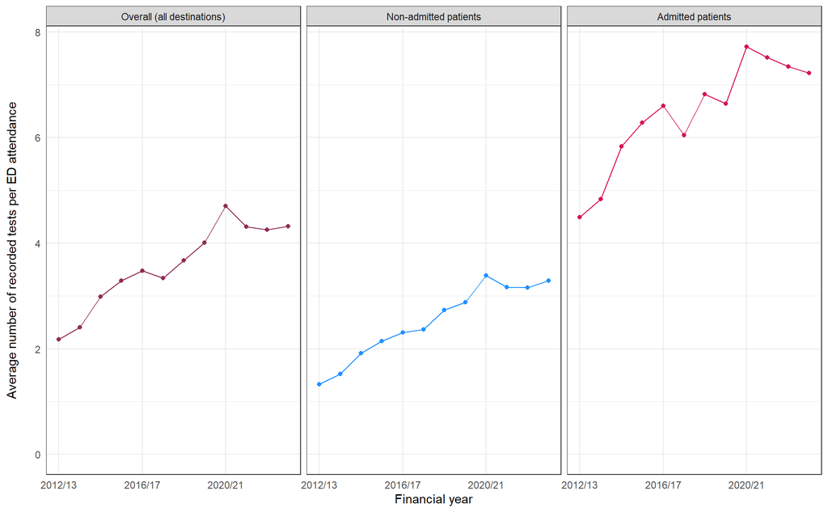

**Results by test group**

Figure 2: Estimated average number of tests per ED attendance, in England, between 2012/13 and 2023/24. Results by broad test group.

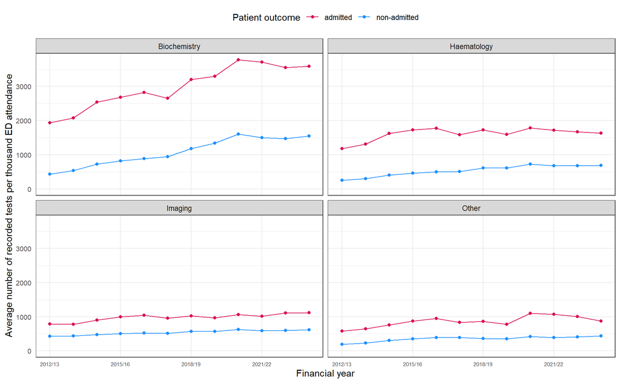

**Results by test type**

Figure 3: Estimated average number of tests per ED attendance (with local regression), in England, between 2012/13 and 2023/24. Results by A&E dataset test type.

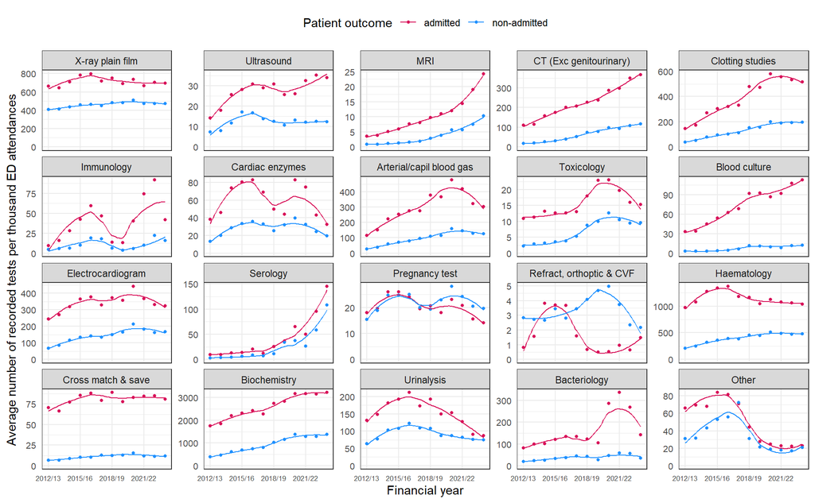

**Table**

Estimated average number of tests per ED attendance, in England, between 2012/13 and 2023/24. Source: SUS A&E and EC data sets.

| Financial year | Destination type | Attendances in sample | Attendance growth on previous year | Tests in sample | Test growth on previous year | Tests per attendance |
| --- | --- | --- | --- | --- | --- | --- |
| 2012/13 | Overall (all destinations) | 3,004,000 | NA | 6,534,000 | NA | 2.17 |
| 2013/14 | Overall (all destinations) | 3,100,000 | 3.2% | 7,467,000 | 14.3% | 2.41 |
| 2014/15 | Overall (all destinations) | 3,318,000 | 7.0% | 9,895,000 | 32.5% | 2.98 |
| 2015/16 | Overall (all destinations) | 3,447,000 | 3.9% | 11,320,000 | 14.4% | 3.28 |
| 2016/17 | Overall (all destinations) | 3,505,000 | 1.7% | 12,190,000 | 7.7% | 3.48 |
| 2017/18 | Overall (all destinations) | 3,536,000 | 0.9% | 11,800,000 | −3.2% | 3.34 |
| 2018/19 | Overall (all destinations) | 3,558,000 | 0.6% | 13,080,000 | 10.8% | 3.68 |
| 2019/20 | Overall (all destinations) | 2,901,000 | −18.4% | 11,620,000 | −11.2% | 4.00 |
| 2020/21 | Overall (all destinations) | 2,627,000 | −9.5% | 12,360,000 | 6.4% | 4.71 |
| 2021/22 | Overall (all destinations) | 3,449,000 | 31.3% | 14,870,000 | 20.3% | 4.31 |
| 2022/23 | Overall (all destinations) | 3,440,000 | −0.3% | 14,620,000 | −1.7% | 4.25 |
| 2023/24 | Overall (all destinations) | 3,462,000 | 0.6% | 14,950,000 | 2.2% | 4.32 |
| 2012/13 | Non-admitted patients | 2,196,000 | NA | 2,904,000 | NA | 1.32 |
| 2013/14 | Non-admitted patients | 2,269,000 | 3.3% | 3,452,000 | 18.9% | 1.52 |
| 2014/15 | Non-admitted patients | 2,415,000 | 6.5% | 4,631,000 | 34.2% | 1.92 |
| 2015/16 | Non-admitted patients | 2,498,000 | 3.4% | 5,358,000 | 15.7% | 2.15 |
| 2016/17 | Non-admitted patients | 2,551,000 | 2.1% | 5,894,000 | 10.0% | 2.31 |
| 2017/18 | Non-admitted patients | 2,604,000 | 2.1% | 6,166,000 | 4.6% | 2.37 |
| 2018/19 | Non-admitted patients | 2,739,000 | 5.2% | 7,491,000 | 21.5% | 2.74 |
| 2019/20 | Non-admitted patients | 2,035,000 | −25.7% | 5,865,000 | −21.7% | 2.88 |
| 2020/21 | Non-admitted patients | 1,827,000 | −10.2% | 6,183,000 | 5.4% | 3.38 |
| 2021/22 | Non-admitted patients | 2,540,000 | 39.1% | 8,039,000 | 30.0% | 3.16 |
| 2022/23 | Non-admitted patients | 2,539,000 | −0.1% | 8,006,000 | −0.4% | 3.15 |
| 2023/24 | Non-admitted patients | 2,552,000 | 0.5% | 8,384,000 | 4.7% | 3.28 |
| 2012/13 | Admitted patients | 808,000 | NA | 3,630,000 | NA | 4.49 |
| 2013/14 | Admitted patients | 831,000 | 2.8% | 4,016,000 | 10.6% | 4.83 |
| 2014/15 | Admitted patients | 903,100 | 8.7% | 5,265,000 | 31.1% | 5.83 |
| 2015/16 | Admitted patients | 948,900 | 5.1% | 5,962,000 | 13.2% | 6.28 |
| 2016/17 | Admitted patients | 954,200 | 0.6% | 6,299,000 | 5.7% | 6.60 |
| 2017/18 | Admitted patients | 932,200 | −2.3% | 5,634,000 | −10.6% | 6.04 |
| 2018/19 | Admitted patients | 819,000 | −12.1% | 5,584,000 | −0.9% | 6.82 |
| 2019/20 | Admitted patients | 866,600 | 5.8% | 5,752,000 | 3.0% | 6.64 |
| 2020/21 | Admitted patients | 800,300 | −7.6% | 6,180,000 | 7.4% | 7.72 |
| 2021/22 | Admitted patients | 908,800 | 13.6% | 6,832,000 | 10.5% | 7.52 |
| 2022/23 | Admitted patients | 901,300 | −0.8% | 6,618,000 | −3.1% | 7.34 |
| 2023/24 | Admitted patients | 909,300 | 0.9% | 6,564,000 | −0.8% | 7.22 |

## A2. To what extent can changes in ED patient casemix explain the growth in test rates?

The number and types of test that a patient receives in ED will be influenced by the patient’s characteristics and presenting conditions. The term “casemix” can be used to describe the combination of these factors. In this section of analysis, we explore whether patients are more or less likely to receive a test in 2023/24 than in 2019/20, having taken account of the patient casemix. The results are expressed as casemix-adjusted odds ratios, which is the odds of a patient receiving a test in 2023/24 divided by the odds in 2019/20, having adjusted for changes in casemix between the two years. We perform these calculations for 32 tests. These 32 tests account for over 99% of all tests recorded in EDs.

**A2: Method and Limitations (click to unhide)**

**A2: Method**

We used the SUS EC data set and identified 16 providers with provider codes that survived across the study period and that passed our data quality criteria for this question. For further details of our sampling approach and data quality criteria see Section 3.0.1 and Section 7.

In terms of data preparation, we removed March from both 2019/20 and 2023/24, to avoid any bias in our results that may have arisen due to the onset of the pandemic in March 2020.

Approximately 4% of the 3 million records had missing values in a key field (our “key fields” are given in Section 7). The specified model type will not accept missing values, so we chose to delete the records with missing values in our key fields.

We performed logistic regressions using generalised additive models (GAMs) with mixed-effects. All 32 models were specified in the same way, with the only difference being the binary dependent variable (whether the given test was carried out). Our fixed effects included the variable of interest, financial year, and several time-related variables to control for season, weekday, and time of arrival. We included variables to adjust for casemix (as far as possible), namely: *age* (as a spline-based smooth) interacting with *sex*; a re-engineered *chief complaint* variable; *acuity*; *arrival mode*; and *referral source*.

(It is important to note that the *chief complaint* and *acuity* variables are recorded as part of an initial assessement ([NHSE, 2022](https://www.england.nhs.uk/guidance-for-emergency-departments-initial-assessment/#:~:text=chief%20complaint%20or%20suspected%20diagnosis,initially%20assessed%20by%20a%20clinician)). They are therefore akin to presentation codes. Whilst the diagnosis codes may give greater detail about a patient’s condition (and better allow us to control for casemix), diagnosis is often a causal consequence of testing and it would therefore be inappropriate to use diagnosis-related information to predict whether a patient receives a given test.)

We treated the provider variable as a random effect. This allowed us to control for factors that vary, at random, across providers. Moreover, the values produced by this random effect can be thought of as sample values from a larger population of values. As the providers in our data set were, in fact, a sample of all providers, this approach suits our case well.

We ran each model on the same random sub-sample of 1 million attendance records.

**A2: Limitations**

The findings of this analysis are based on a sample of 16 providers (of 102 providers whose provider codes remained unchanged over the study period). These findings are therefore subject to the same sampling-related limitations we identified in the Limitations section of A1.

We have labelled our estimates as “casemix-adjusted” as we controlled for a range of variables that might indicate a patient’s need for a test. However, a clinician will order a test based on an array of factors and only some of these will be recorded in data sets. Therefore, as we are unable to control for unrecorded variables, part of the effect we measure may be due to unobserved case mix factors.

Finally, as noted in the Methods section above, we decided to delete approximately 4% of records from our sample that had missing values for any of the variables used in the model. We expect this decision to have a limited impact on our results. However, as it reduced our sample size, the standard errors around our model coefficients have marginally increased as a consequence. There is also the potential for some bias in our results if these missing data were not missing completely at random.

**A2: Results**

Figure 4 and Figure 5 suggest that for most tests provided in EDs, patients were more likely to receive the test in 2023/24 than they were in 2019/20. In many cases, the increased odds of receiving a test were substantial. The adjusted odds of receiving the following tests increased by between 50% and 100%: hepatic function panel; CT scan; bone profile; analysis of arterial blood gases and pH; D-dimer assay; creatine kinase measurement; and MRI scan. Moreover, the adjusted odds of receiving C-reactive protein; urine sent for culture; serum lactate measurement; wound microscopy culture and sensitivities; lipid panel; and serologic tests more than doubled.

For 6 of the 32 tests, the odds of receiving the test *fell* between 2019/20 and 2023/24. These tests were: erythrocyte sedimentation rate measurement, group and save, electrocardiography, serum lipase measurement, urinalysis, and human chorionic gonadotropin measurement.

We can compare the increased odds of testing estimated here, with similar analysis covering the period 2012/13 to 2019/20. This comparison suggests that the increase in the casemix-adjusted odds of a patient receiving a CT scan has fallen, from +19% per annum between 2012/13 and 2019/20, to +16% per annum between 2019/20 and 2023/24. There has been a similar slowdown in the rate of increase for MRI scans (from 25% per annum between 2012/13 and 2019/20, to 17% per annum between 2019/20 and 2023/24).

**Graphic(excl. serological testing)**

Figure 4: Case-mix-adjusted odds-of-test ratios (2023/24 vs 2019/20), excluding serological testing.

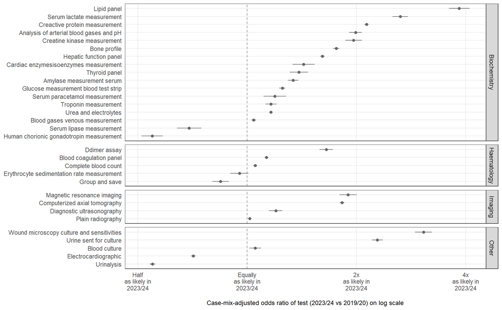

**Graphic(incl. serological testing)**

Figure 5: Case-mix-adjusted odds-of-test ratios (2023/24 vs 2019/20), including serological testing.

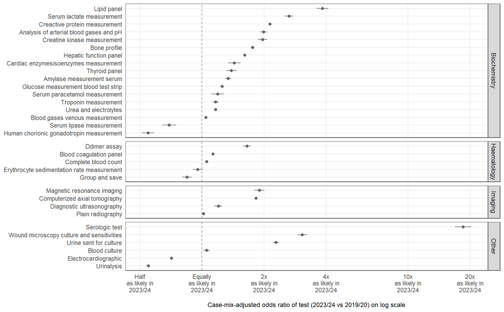

**Table**

Case-mix-adjusted odds-of-test ratios (2023/24 vs 2019/20)

| Test name | Attendances in sub-sample 2023/24 | Tests in sub-sample 2023/24 | Odds ratio of test (casemix adj.) 2023/24 vs. 2019/20 | lci | uci |
| --- | --- | --- | --- | --- | --- |
| Urea and electrolytes | 566,031 | 260,180 | 1.163 | 1.149 | 1.176 |
| Complete blood count | 566,031 | 232,652 | 1.054 | 1.041 | 1.066 |
| Plain radiography | 566,031 | 204,780 | 1.017 | 1.007 | 1.028 |
| Blood coagulation panel | 566,031 | 146,433 | 1.131 | 1.118 | 1.144 |
| Hepatic function panel | 566,031 | 137,267 | 1.612 | 1.59 | 1.633 |
| Creactive protein measurement | 566,031 | 141,212 | 2.134 | 2.106 | 2.162 |
| Electrocardiographic | 566,031 | 83,394 | 0.711 | 0.702 | 0.721 |
| Blood gases venous measurement | 566,031 | 77,732 | 1.043 | 1.028 | 1.059 |
| Computerized axial tomography | 566,031 | 78,225 | 1.826 | 1.798 | 1.855 |
| Bone profile | 566,031 | 45,627 | 1.761 | 1.726 | 1.796 |
| Urinalysis | 566,031 | 27,892 | 0.549 | 0.539 | 0.559 |
| Glucose measurement blood test strip | 566,031 | 34,247 | 1.251 | 1.227 | 1.275 |
| Amylase measurement serum | 566,031 | 28,109 | 1.34 | 1.295 | 1.386 |
| Troponin measurement | 566,031 | 27,555 | 1.164 | 1.123 | 1.206 |
| Urine sent for culture | 566,031 | 27,503 | 2.285 | 2.208 | 2.366 |
| Analysis of arterial blood gases and pH | 566,031 | 22,665 | 1.99 | 1.911 | 2.072 |
| Blood culture | 566,031 | 17,462 | 1.054 | 1.015 | 1.094 |
| Serum lactate measurement | 566,031 | 16,672 | 2.643 | 2.517 | 2.774 |
| Ddimer assay | 566,031 | 16,738 | 1.653 | 1.584 | 1.724 |
| Creatine kinase measurement | 566,031 | 13,495 | 1.966 | 1.867 | 2.071 |
| Lipid panel | 566,031 | 15,152 | 3.843 | 3.601 | 4.102 |
| Serologic test | 566,031 | 15,978 | 18.515 | 16.885 | 20.303 |
| Group and save | 566,031 | 7,813 | 0.845 | 0.802 | 0.891 |
| Cardiac enzymesisoenzymes measurement | 566,031 | 7,973 | 1.432 | 1.335 | 1.536 |
| Thyroid panel | 566,031 | 7,298 | 1.389 | 1.31 | 1.473 |
| Serum paracetamol measurement | 566,031 | 5,604 | 1.193 | 1.11 | 1.281 |
| Human chorionic gonadotropin measurement | 566,031 | 4,815 | 0.548 | 0.512 | 0.587 |
| Serum lipase measurement | 566,031 | 5,219 | 0.693 | 0.641 | 0.749 |
| Diagnostic ultrasonography | 566,031 | 5,772 | 1.2 | 1.151 | 1.252 |
| Wound microscopy culture and sensitivities | 566,031 | 6,931 | 3.064 | 2.903 | 3.233 |
| Magnetic resonance imaging | 566,031 | 5,144 | 1.898 | 1.796 | 2.006 |
| Erythrocyte sedimentation rate measurement | 566,031 | 3,273 | 0.953 | 0.9 | 1.009 |

## A3. What are the implications of this growth for the timeliness of care in ED?

Patients will wait while tests are ordered and conducted, and they will likely wait while their clinician or clinical team interprets and communicates the results. However, tests can provide critical information that allows a patient’s care to be expedited.

Analysis A3 is composed of two parts. In the first part (3.1), we investigate the association between testing - specifically, the addition of a single test to a patient’s care - and the time that a patient spends in the ED. In the second part (3.2), we examine the relationship between the number of tests that a patient receives and their duration in the ED.

**A3.1**

Here, we investigate the association between testing and the time that patients spend in the ED. We examine 32 tests in the 2023/24 financial year and measure the effect for a single additional test, acknowledging that many patients receive several tests (of different types or of the same type). Our results take patient casemix into account.

**A3: Method and Limitations (click to unhide)**

**A3.1:** **Method**

This analysis again uses patient-level data from the 16 providers that passed our consistency and data quality criteria for A2-A4. (For further details of our sampling approach and data quality criteria see Section 3.0.1 and Section 7.) We use only records from the 2023/24 financial year for this analysis.

As in Analysis 2, we deleted records that had missing values in a key field (our “key fields” are given in Section 7). We also removed records with times that appeared to be poorly recorded. For example, there were attendances in which the arrival time was noted as occurring after the assessment time, and those in which the total time in the ED was recorded to be less than zero minutes. We also limited this analysis to attendances where the patient is recorded to have stayed in the ED for less than 30 hours. And we removed a low number of records in which the patient appeared to receive one (or more) test and then left the ED within 15 minutes. All these exclusions reduced our total sample of 1.8 million records by 6.7%.

We chose our dependent variable to be the duration from a patient’s assessment by a clinician to their departure from the ED. The distribution of this variable is heavily right-skewed, and the presence of such a skew in the dependent variable is often cited as a reason to avoid the linear regression model. Specifically, given this distribution, we cannot expect residuals to be normally distributed or display constant variance (which are two key assumptions of the linear model). Thus, typical methods to calculate standard errors and confidence intervals will be biased (though point estimates from such a model remain unbiased).

If, however, we choose popular alternatives to linear regression in this scenario, we are likely to end up with less interpretable, less useful results. Our solution, here, was to employ an approach often used in the field of Econometrics. We implemented a linear regression model but used a heteroscedasticity-consistent (HC) estimator to obtain the covariance of the model parameters, and obtain robust estimates of standard errors and confidence intervals. We chose the estimator recommended by Long and Ervin ([2000](https://www.tandfonline.com/doi/abs/10.1080/00031305.2000.10474549)), known as HC3.

We employed a generalised additive model (GAM) with mixed-effects. We included a separate variable for 42 of the 48 tests recorded in the ECDS (we excluded 6 very low frequency tests). Unlike A2, where the test variable was binary (test conducted or not), these variables measured the number of times a patient received a test. Other fixed effects included month, weekday, and hour of arrival, and we included several variables to adjust for casemix (as far as this is possible), namely: *age* (as a spline-based smooth) interacting with *sex*; a re-engineered *chief complaint* variable; *acuity*; *arrival mode*; and *referral source*.

(It is important to note that the *chief complaint* and *acuity* variables are recorded as part of an initial assessement ([NHSE, 2022](https://www.england.nhs.uk/guidance-for-emergency-departments-initial-assessment/#:~:text=chief%20complaint%20or%20suspected%20diagnosis,initially%20assessed%20by%20a%20clinician)). They are therefore akin to presentation codes. Whilst diagnosis codes may give us greater detail about a patient’s condition (and better allow us to control for casemix), diagnosis is often a causal consequence of testing. If we were to include both tests and diagnoses in our model, we may fail to isolate the influence of tests on the time a patient spends in the ED.)

We treated the provider variable as a random effect. This allowed us to control for factors that vary, at random, across providers. Moreover, the values produced by this random effect can be thought of as sample values from a larger population of values. As the providers in our data set were, in fact, a sample of all providers, this approach suits our case well.

We ran the model on a random sub-sample of 1 million attendance records.

**A3.1: Limitations**

The findings of this analysis are based on a sample of 16 providers. These findings are therefore subject to the same sampling-related limitations we identified in the Limitations section of A1. Of relevance to A3, are the representation statistics in Section 7 that indicate that the performance of providers in Sample 2 (in terms of 4-hour and 12-hour waits) is somewhat lower than that of the population of providers. This may have a bearing on the sizes of the effects that we report.

We have labelled our estimates as “casemix-adjusted”, as we controlled for a range of variables that might indicate the time a patient spends in the ED. However, we are unable to control for casemix factors that influence decisions (and time spent) in the ED, but go unrecorded. It is therefore possible that part of the effect we measure is due to unobserved casemix factors.

For reasons related to model interpretabilty, we specified a linear relationship between the number of times a test is conducted and the time a patient spends in an ED. In reality, the relationship is likely to be non-linear. That said, in most cases, a patient will receive only one test of a particular type. We therefore decided that the disadvantages of a linear assumption were modest and the advantages (over a non-linear assumption), clear.

Our results estimate the time impact of a single additional test on a patient’s stay in the ED. We acknowledge that many patients receive several tests, of different types or the same type. With regression models, we have the ability to specify interactions between test terms (to account for the effect of one test, given the provision of another). However, this approach is impractical here, based both on the number of interaction terms we would produce and on our desire for interpretability.

Finally, as noted in the Methods section of A3.1, above, we removed approximately 7% of records from our sample due to poor data quality. We expect this decision to have a limited impact on our results. However, as it reduced our sample size, the standard errors around our model coefficients will have increased as a consequence. There is also the potential for some bias in our results if these missing data were not missing completely at random.

**A3.1: Results**

We found statistically significant evidence that 23 of the 32 we considered were associated with a longer stay in the ED (see Figure 6). MRI scans had the biggest impact, being associated with an increase of 3 hours, on average, to a patient’s stay. Other forms of imaging, namely CT scan and ultrasound, and two other tests (urine sent for culture, and analysis of arterial blood gas and pH) were associated with an increased stay of 60 to 90 minutes in the ED.

Given these findings, it may be tempting to infer that tests lead to longer stays in the ED. There is good reason to believe this might be the case: it takes time to order and conduct tests, and to incorporate results into a patient’s treatment plan. However, an alternative explanation also exists: it may be that longer stays in ED - perhaps due to lack of beds (“exit block”) - lead to additional tests. Whilst this analysis is not capable of distinguishing between these two potential causal explanations, we set out how such work might be carried out in Section 6.

We found evidence that 5 tests were associated with *shorter* stays in EDs: lipid panel, glucose measurement blood test strip, serum lactate measurement, amylase measurement serum, and group and save tests. In most cases, this effect was modest. The effect for lipid panel was more marked, but these tests occurred at comparatively low frequency, and no clear and plausible explanation for this finding can be offered.

For 4 tests, we were unable to establish with confidence whether the test was associated with an increased or decreased time in the ED.

An earlier study explored this question for EDs in the US, in the years from 2006 to 2008, using subtly different methods. The authors concluded that the tests that had the greatest marginal impact on ED stays were blood tests (+72 mins); MRI scans (+64 mins); CT scans (+59 mins); and ultrasound scans (+56 mins). It is important to note that testing methods, technology, and efficiency have changed substantially in the 15 years that have passed since the study period.

The potential materiality of these findings for ED patient flow in general (as opposed to the journey of a single patient) can be examined by considering both the time impact of the test and the test frequency. From this perspective, the tests that would appear to have the biggest potential impact on patient flow are likely to be CT scans, plain radiography, urea and electrolytes, complete blood count, and C-reactive protein measurement. Of these, we note that the casemix adjusted odds of receiving a CT scan and C-reactive protein measurement have increased considerably since 2019/20.

**Graphic**

Figure 6: Estimated (net) time that 32 different ED tests add to an attendance, on average.

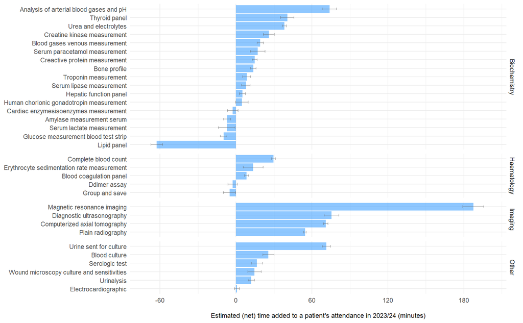

**Table**

Table 2: Estimated (net) time that 32 different ED tests add to an attendance, on average.

| Test name | Minutes added (net, on average) | lci | uci | Number of tests (in sample) 23/24 | Growth in # tests 19/20 to 23/24 |
| --- | --- | --- | --- | --- | --- |
| Magnetic resonance imaging | 188 | 179 | 196 | 18,160 | 244% |
| Diagnostic ultrasonography | 75 | 70 | 81 | 19,960 | 144% |
| Analysis of arterial blood gases and pH | 74 | 68 | 79 | 72,500 | 157% |
| Urine sent for culture | 71 | 68 | 75 | 95,570 | 225% |
| Computerized axial tomography | 71 | 69 | 73 | 306,800 | 193% |
| Plain radiography | 54 | 53 | 56 | 812,800 | 134% |
| Thyroid panel | 41 | 35 | 46 | 28,240 | 187% |
| Urea and electrolytes | 38 | 37 | 40 | 1,014,000 | 127% |
| Complete blood count | 30 | 28 | 31 | 928,000 | 127% |
| Creatine kinase measurement | 26 | 22 | 30 | 48,550 | 236% |
| Blood culture | 26 | 21 | 30 | 59,330 | 127% |
| Blood gases venous measurement | 19 | 17 | 22 | 252,200 | 117% |
| Serum paracetamol measurement | 17 | 11 | 23 | 23,060 | 128% |
| Serologic test | 17 | 12 | 21 | 57,410 | 860% |
| Creactive protein measurement | 15 | 13 | 17 | 486,000 | 176% |
| Wound microscopy culture and sensitivities | 15 | 9 | 20 | 24,470 | 294% |
| Bone profile | 14 | 12 | 16 | 194,100 | 258% |
| Erythrocyte sedimentation rate measurement | 14 | 6 | 21 | 11,180 | 137% |
| Urinalysis | 12 | 10 | 15 | 88,690 | 75% |
| Troponin measurement | 9 | 5 | 12 | 95,920 | 143% |
| Blood coagulation panel | 8 | 7 | 10 | 556,700 | 130% |
| Serum lipase measurement | 8 | 5 | 11 | 32,460 | 203% |
| Hepatic function panel | 5 | 3 | 7 | 458,400 | 154% |
| Human chorionic gonadotropin measurement | 5 | 0 | 10 | 16,670 | 92% |
| Electrocardiographic | 1 | −1 | 3 | 273,100 | 100% |
| Cardiac enzymesisoenzymes measurement | −3 | −7 | 2 | 32,160 | 121% |
| Ddimer assay | −3 | −6 | 1 | 54,830 | 209% |
| Group and save | −5 | −10 | 0 | 31,760 | 115% |
| Amylase measurement serum | −7 | −10 | −4 | 97,180 | 142% |
| Serum lactate measurement | −7 | −14 | −1 | 53,220 | 181% |
| Glucose measurement blood test strip | −10 | −12 | −7 | 119,700 | 130% |
| Lipid panel | −63 | −67 | −58 | 52,140 | 543% |

**A3.2**

As the number of tests per attendance has increased, so has the number of patients who receive several tests. Here, we examine the relationship between the number of tests that a patient receives and their duration in the ED. We describe this relationship in 2019/20 and in 2023/24. Unlike A2 and A3.1, this analysis is not casemix-adjusted, since the methods that are usually employed to adjust for casemix are unlikely to be adequate in this context.

**A3.2: Method and Limitations (click to unhide)**

**A3.2:** **Method**

This analysis uses patient-level data from the 16 providers that passed our consistency and data quality criteria for A2-A4. (For further details of our sampling approach and data quality criteria see Section 3.0.1 and Section 7.)

In terms of data preparation, we removed March from both 2019/20 and 2023/24, to avoid any bias to our results that may have arisen due to the onset of the pandemic in March 2020.

We removed records with times that appeared to be poorly recorded. For example, there were attendances in which the arrival time was noted as occurring after the assessment time, and those in which the total time in the ED was recorded to be less than zero minutes. These data quality exclusions reduced our total sample of 3 million records by 2%.

Our dependent variable was the average duration from a patient’s assessment by a clinician to their departure from the ED. The distribution of this variable is heavily right-skewed, so we used the median time, rather than the mean time, to limit the impact of extreme values.

**A3.2: Limitations**

The findings in this section are based on a sample of 16 providers and are therefore subject to the same sampling-related limitations we identified in the Limitations section of A1.

It is to be expected that more complex patients have more tests and so stay longer in the ED. Our results are not casemix-adjusted, and it is therefore possible that some of the effect we report might be attributable to patient casemix.

**A3.2: Results**

Figure 7 shows that, in general, a patient’s (unadjusted) stay in an ED tends to increase with the number of tests performed. This relationship can be explained in part with reference to patient casemix (more complex patients have more tests and stay longer), but also because, as we have seen above, most tests add time to a patient’s stay.

However, the nature of this relationship has changed between 2019/20 and 2023/24. In 2019/20, 28 minutes was added to a patients stay, on average, for each of the first 5 tests performed. But the impact of each additional test beyond the fifth was limited, adding on average only 7 minutes per test. By 2023/24, the time patients were spending in the ED had increased considerably. Each of the first five tests now added 44 minutes on average. Moreover, for each additional test beyond the fifth, the time in ED continued to rise considerably - by 38 minutes per test. This change can be seen whether the patient was admitted or discharged, and whether the patient was treated for an injury or an illness (although subtle differences in the relationship are present (see appendix)).

Whilst this finding is clear in the data, it is not easy to explain. One potential line of enquiry would focus on the extent of asynchronous testing. The result might also be an emergent property of a system operating with reduced flow, which manifests as re-testing of patients whose care is delayed.

Additional (exploratory) plots relating to this question can be found in Section 9.

Figure 7: Median time in ED by number of tests.

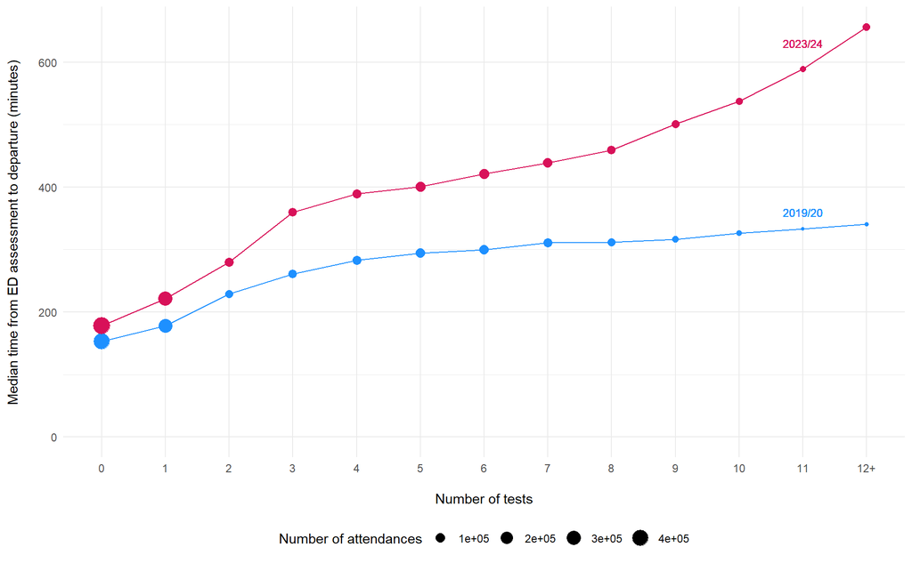

## A4. What are the implications of this growth for decisions to admit?

In this section, we explore how increased testing in EDs has influenced the rate of admissions to hospital beds. We do this by comparing the change in the casemix-adjusted *odds of a test* with the casemix-adjusted *odds of admission* *having received a test*. We examine these changes over the period from 2019/20 to 2023/24, for 32 test types.

**A4: Methods and Limitations**

**A4: Method**

We used the SUS EC data set and identified 16 providers with provider codes that survived across the study period and that passed our data quality criteria for this question. For further details of our sampling approach and data quality criteria see Section 3.0.1 and Section 7.

We used two types of model for this analysis. The first provided the casemix-adjusted odds of a test (for which methods and limitations can be found under A2) and the second produced the casemix-adjusted odds of *admission* *having received a test*. We provide details of the latter model here.

In terms of data preparation, we removed March from both 2019/20 and 2023/24, to avoid any bias to our results that may have arisen due to the onset of the pandemic in March 2020.

Approximately 4% of the 3 million records had missing values in a key field (our “key fields” are given in Section 7). Our specified model type will not accept missing values, so we chose to delete the records with missing values in our key fields.

We performed logistic regression by way of a generalised additive model (GAM) with mixed-effects. Our dependent variable was a binary indicator of whether a patient was admitted following the ED attendance. Our fixed effects included a separate binary variable (test conducted or not) for every one of the 48 tests recorded in the ECDS. Other fixed effects included month, weekday, and hour of arrival, and we included several variables to adjust for casemix (as far as this is possible), namely: *age* (as a spline-based smooth) interacting with *sex*; a re-engineered *chief complaint* variable interacting with *arrival mode*; *acuity*; and *referral source*.

Our variables of interest were interactions between each binary test variable and the financial year variable.

We treated the provider variable as a random effect. This allowed us to control for factors that vary, at random, across providers. Moreover, the values produced by this random effect can be thought of as sample values from a larger population of values. As the providers in our data set were, in fact, a sample of all providers, this approach suits our case well.

We ran the model on a random sub-sample of 1 million attendance records.

**A4: Limitations**

The findings of this analysis are based on a sample of 16 providers. These findings are therefore subject to the same sampling-related limitations we identified in the Limitations section of A1.

We have labelled our estimates as “casemix-adjusted”, as we controlled for a range of variables that might indicate a patient’s risk of admission. However, there will be variables influencing a patient’s risk of admission that go unrecorded. Because we are unable to control for unrecorded variables, our casemix adjustment is only partial. It is therefore possible that some of the effect we see is due to this unobserved casemix effect.

- the change in the casemix-adjusted odds of a test, and
- the change in the casemix-adjusted odds of admission having received a test.

The graphic shows 19 (of the original 32) tests for which the calculated odds-ratios are statistically significant in both dimensions.

Many of the tests - including most of the high-volume tests - fall into the bottom-right quadrant. This indicates that, after adjusting for casemix, patients were more likely to receive the test in 2023/24, but less likely to be admitted having received it. This is true for complete blood count; C-reactive protein measurement; hepatic function panel; and urea and electrolytes.

Finally, there are two low-volume tests that appear to be outliers in this analysis: wound microscopy culture and sensitivities; and lipid panel. These appear in the top-right quadrant, but some way from the origin. Their position indicates that patients were much more likely to receive these tests in 2023/24, and much more likely to be admitted having received the test. However, given the use cases for these tests, it does not seem plausible that they are being used to identify patients who require admission. It is more likely that these tests are being performed on patients after it becomes clear that admission is required. Furthermore, this result is subject to high levels of statistical uncertainty because the number of these tests that were performed in the baseline year (2019/20) was low.

**Graphic (excl. serological tests)**

Figure 8: Casemix-adjusted odds ratio of test, and of admission having received the test, 2023/24 vs 2019/20. (Excluding serological tests)

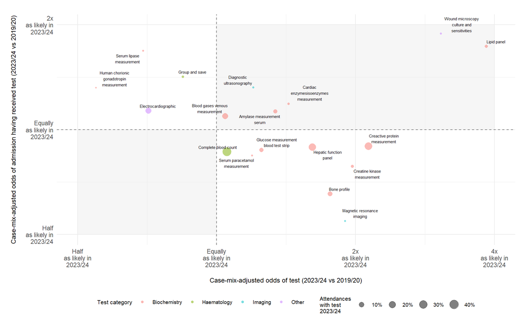

**Graphic (incl. serological tests)**

Figure 9: Casemix-adjusted odds ratio of test, and of admission having received the test, 2023/24 vs 2019/20. (Including serological tests)

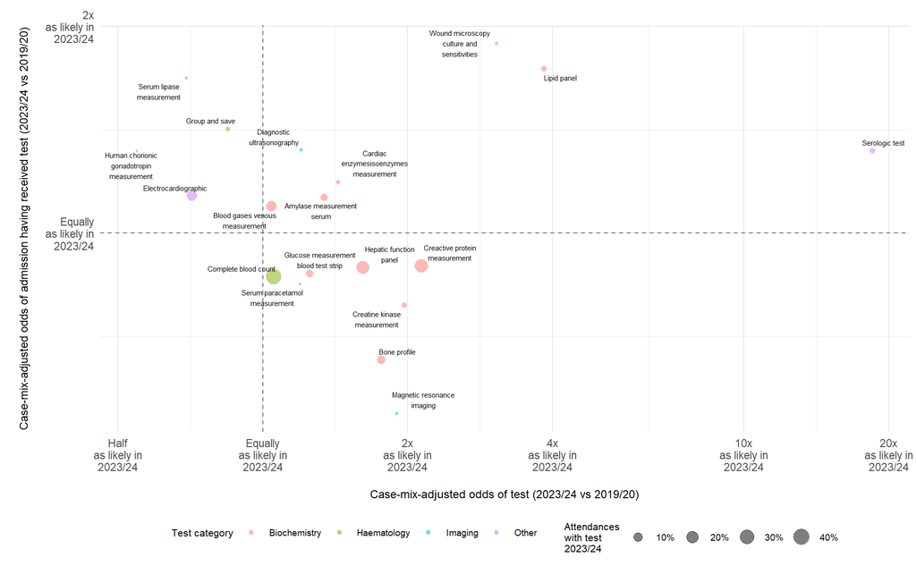

**Table**

Table 3: Casemix-adjusted odds ratio of admission having received a test, 2023/24 vs 2019/20.

| Test name | Odds ratio of test (casemix adj.) 2023/24 vs. 2019/20 | Odds ratio of admission given test (casemix adj.) 2023/24 vs. 2019/20 | OR admission p value |
| --- | --- | --- | --- |
| Urea and electrolytes | 1.163 | 0.941 | 0.150 |
| Complete blood count | 1.054 | 0.864 | 0.000 |
| Plain radiography | 1.017 | 1.006 | 0.766 |
| Blood coagulation panel | 1.131 | 0.968 | 0.230 |
| Hepatic function panel | 1.612 | 0.891 | 0.001 |
| Creactive protein measurement | 2.134 | 0.896 | 0.001 |
| Electrocardiographic | 0.711 | 1.133 | 0.000 |
| Blood gases venous measurement | 1.043 | 1.094 | 0.005 |
| Computerized axial tomography | 1.826 | 0.98 | 0.493 |
| Bone profile | 1.761 | 0.654 | 0.000 |
| Urinalysis | 0.549 | 0.988 | 0.771 |
| Glucose measurement blood test strip | 1.251 | 0.874 | 0.001 |
| Amylase measurement serum | 1.34 | 1.129 | 0.007 |
| Troponin measurement | 1.164 | 1.015 | 0.748 |
| Urine sent for culture | 2.285 | 1.046 | 0.408 |
| Analysis of arterial blood gases and pH | 1.99 | 0.914 | 0.171 |
| Blood culture | 1.054 | 1.02 | 0.775 |
| Serum lactate measurement | 2.643 | 1.065 | 0.458 |
| Ddimer assay | 1.653 | 1.066 | 0.319 |
| Creatine kinase measurement | 1.966 | 0.785 | 0.001 |
| Lipid panel | 3.843 | 1.735 | 0.000 |
| Serologic test | 18.515 | 1.317 | 0.037 |
| Group and save | 0.845 | 1.419 | 0.000 |
| Cardiac enzymesisoenzymes measurement | 1.432 | 1.188 | 0.031 |
| Thyroid panel | 1.389 | 1.098 | 0.308 |
| Serum paracetamol measurement | 1.193 | 0.843 | 0.045 |
| Human chorionic gonadotropin measurement | 0.548 | 1.318 | 0.003 |
| Serum lipase measurement | 0.693 | 1.684 | 0.000 |
| Diagnostic ultrasonography | 1.2 | 1.321 | 0.003 |
| Wound microscopy culture and sensitivities | 3.064 | 1.887 | 0.000 |
| Magnetic resonance imaging | 1.898 | 0.547 | 0.000 |
| Erythrocyte sedimentation rate measurement | 0.953 | 1.029 | 0.816 |

# Conclusion

In this analysis, we investigated how rates of diagnostic testing in EDs have changed in recent years. We also explored how these changes have influenced both patient journeys through EDs and the likelihood of admission to hospital. The analysis highlights the complex interplay between test thresholds, admission thresholds, and the timeliness of care in EDs. Given the constraints under which our health system operates, it may not be possible to optimise these three quantities simultaneously. Trade-off decisions are likely required, at least in the short term. In the second phase of this project, we plan to address the first of the *further research* questions listed below, which we hope will inform these challenging decisions.

# Further Research

We describe, below, four potential projects that might develop or confirm the story emerging from this analysis.

#### Are ED test thresholds falling in response to lack of bed availability or proactive changes in medical practice?

Our provisional analysis indicates that the casemix-adjusted odds of receiving a test have increased in recent years. This effect is present for most, but not all tests. Furthermore, we find that the casemix-adjusted odds of admission having had a test, have reduced. These two changes may be causally related. Our theory is that by testing more, clinicians are able to rule out conditions that would otherwise involve admission. It is unclear, however, if clinical practice in EDs is leading this change, or if practice is responding to changes in the operational context, and in particular to the reduced availability of beds. One way to explore this issue would be to develop regression models to examine whether, and the extent to which, the odds of a patient receiving a test, varies with bed occupancy, having controlled for casemix, temporal, and provider effects. Rather than explore these effects for all tests, we suggest a focus on two or three common tests (e.g. CT scan, C-reactive protein, full blood count). Evidence of such an effect would indicate that increased testing may be, in part, driven by reduced bed availability.

#### Is there any evidence that increased admission thresholds via ED have led to adverse patient outcomes?

Increases in admission thresholds via ED have clear system benefits. Hospital beds are in short supply, and emergency admissions are costly. But it would be prudent to assess whether increased admission thresholds have led to adverse patient effects. Two readily measurable adverse events are (1) unplanned reattendance, and (2) unexpected death, within 7 days of discharge from ED. A 2017 US study, estimated the number of patients that die in the seven days after discharge from ED despite no diagnosis of a life-limiting condition. Data from NHS Digital suggests that unplanned reattendance rates are increasing in England. We propose a panel data approach to assess the relationship between changes in admission thresholds and changes in the rates of reattendance and unexpected mortality within 7 days of discharge from ED. In effect, we would be testing whether those providers that have seen the greatest increases in admission thresholds have seen the largest increases in adverse events.

#### To what extent do delays in elective pathways lead to increased ED use?

Increases in referral to treatment times for elective pathways have been widely reported. These increases pre-date the COVID-19 pandemic and have risen sharply since mid 2021. Waiting times in emergency departments have followed a similar trajectory, leading some to suggest that these effects may be linked. In particular, there is a question as to whether patients waiting for elective care are at greater risk of an ED attendance. The recent period of industrial action may provide an opportunity to test this theory, since a substantial number of outpatient attendances and elective admissions were cancelled due to strikes. We suggest a matched cohort study, tracking ED attendance rates of patients whose outpatient appointment or elective procedure was cancelled due to a strike, alongside a set of similar patients whose care went ahead on days either side of the strike.

#### How do thresholds for computerised axial tomography in ED vary between providers, and to what extent do these thresholds influence ED flow?

A recent systematic review highlighted excessive or unnecessary use of CT scans in ED, in several countries, and identified strategies that have been successfully used to reduce the use of CT scans without adverse effects. Our analysis found that (1) CT scans occur in high volumes in ED, (2) the threshold for CT scans has fallen considerably in recent years, and (3) a CT scan tends to add between 60 and 90 minutes to a patient’s stay in ED. It is therefore conceivable that unwarranted variation in the thresholds for CT scans in ED is influencing ED performance against the 4-hour target. Moreover, addressing this issue may lead to improvements in ED waiting times without reducing admission thresholds or increasing rates of harm. It may be possible (subject to checks that casemix variables in ECDS enable valid comparisons between providers) to measure an ED’s casemix-adjusted threshold for CT scans over time. Panel data methods could then be used to assess the association between these thresholds and performance against the 4-hour waiting times target.

# Appendix 1

To increase the chances that our findings would be reliable and valid for a given question, we conducted each analysis on data from a sample of providers. We were able to identify two distinct samples that met our needs for the four questions. The first sample, of 28 providers, was used in Analysis 1 (to address Question 1). A second sample, of 16 providers, was used in the analyses relating to Questions 2 to 4.

### Sample used for A1

Given that we were covering a relatively long period, spanning two data sets (with slightly different structures), it was important to understand the quality and consistency of recording practices, both over time and by provider.

We identified 99 providers with provider codes that survived across the 12 year study period and that, in addition, passed basic data quality checks. These 99 providers represent the total population of providers that we might have used for our analysis had data quality been universally high.

Providers were included in our sample if their data submissions met the quality required for this question. Here, the study period is relatively long but we have few variables to examine. We are looking to see that:

1. Throughout the study period, providers have had consistently high levels of recording of the investigation fields.
2. For attendances in which multiple investigations of the same type have been carried out, providers have recorded each instance of the investigation (and have been consistent in this practice over the whole study period).

We established that 28 providers met these criteria. The providers we selected for our sample are given in Table 4. In the adjacent tab, Table 5 suggests that this sample of 28 providers is widely representative of the population of providers. We note that the sample includes higher proportions of larger providers and providers in London, and lower proportions of smaller providers and providers in the East of England.

**Provider sample for A1**

Table 4: Provider sample used in Analysis 1

| id | Provider_Code | Provider_Name |
| --- | --- | --- |
| 1 | R1F | Isle Of Wight NHS Trust |
| 2 | R1H | Barts Health NHS Trust |
| 3 | RAX | Kingston Hospital NHS Foundation Trust |
| 4 | RBL | Wirral University Teaching Hospital NHS Foundation Trust |
| 5 | RDU | Frimley Health NHS Foundation Trust |
| 6 | REF | Royal Cornwall Hospitals NHS Trust |
| 7 | RF4 | Barking, Havering And Redbridge University Hospitals NHS Trust |
| 8 | RHM | University Hospital Southampton NHS Foundation Trust |
| 9 | RJ1 | Guy's And St Thomas' NHS Foundation Trust |
| 10 | RJ2 | The Lewisham And Greenwich NHS Trust |
| 11 | RKB | University Hospitals Coventry And Warwickshire NHS Trust |
| 12 | RLQ | Wye Valley NHS Trust |
| 13 | RM1 | Norfolk And Norwich University Hospitals NHS Foundation Trust |
| 14 | RNS | Northampton General Hospital NHS Trust |
| 15 | RP5 | Doncaster And Bassetlaw Teaching Hospitals NHS Foundation Trust |
| 16 | RPA | Medway NHS Foundation Trust |
| 17 | RQX | Homerton Healthcare NHS Foundation Trust |
| 18 | RR8 | Leeds Teaching Hospitals NHS Trust |
| 19 | RRK | University Hospitals Birmingham NHS Foundation Trust |
| 20 | RTD | The Newcastle Upon Tyne Hospitals NHS Foundation Trust |
| 21 | RTH | Oxford University Hospitals NHS Foundation Trust |
| 22 | RTX | University Hospitals Of Morecambe Bay NHS Foundation Trust |
| 23 | RWA | Hull University Teaching Hospitals NHS Trust |
| 24 | RWY | Calderdale And Huddersfield NHS Foundation Trust |
| 25 | RX1 | Nottingham University Hospitals NHS Trust |
| 26 | RXF | Mid Yorkshire Hospitals NHS Trust |
| 27 | RXN | Lancashire Teaching Hospitals NHS Foundation Trust |
| 28 | RYR | University Hospitals Sussex NHS Foundation Trust |

**Sample representation statistics (A1)**

Table 5: Is the Sample Representative of the Wider Provider Population?

| variable | population | sample | diff |
| --- | --- | --- | --- |
| n_providers | 99 | 28 |  |
| Provider-related (23/24): |  |  |  |
| attendances < 70k | 23.2% | 17.9% | −5.4% |
| attendances 70-94k | 25.3% | 14.3% | −11.0% |
| attendances 95-129k | 26.3% | 25.0% | −1.3% |
| attendances > 130k | 25.3% | 42.9% | 17.6% |
| also_offers_type_3 | 64.6% | 64.3% | −0.3% |
| 4h target < 46% | 29.3% | 25.0% | −4.3% |
| 4h target 46%-57% | 34.3% | 46.4% | 12.1% |
| 4h target >= 58% | 36.4% | 28.6% | −7.8% |
| 0-12h waits < 86% | 32.3% | 42.9% | 10.5% |
| 0-12h waits 86-92% | 35.4% | 32.1% | −3.2% |
| 0-12h waits >= 93% | 32.3% | 25.0% | −7.3% |
| Case-mix-related: |  |  |  |
| arrive_ambulance | 31.2% | 31.5% | 0.3% |
| admitted | 28.2% | 27.8% | −0.4% |
| Patient demographics: |  |  |  |
| age_under_18 | 22.4% | 21.6% | −0.8% |
| age_75_plus | 17.6% | 16.5% | −1.1% |
| urban | 82.9% | 85.8% | 2.9% |
| deprived_20pc | 26.0% | 29.6% | 3.6% |
| region_east_of_england | 12.1% | 3.8% | −8.3% |
| region_london | 13.9% | 20.6% | 6.7% |
| region_midlands | 21.8% | 19.9% | −1.9% |
| region_north_east_and_yorkshire | 19.8% | 25.8% | 6.0% |
| region_north_west | 10.9% | 8.0% | −2.9% |
| region_south_east | 15.4% | 20.4% | 5.0% |
| region_south_west | 6.1% | 1.7% | −4.4% |

### Sample used for A2-A4

To carry out these analyses, we require only the EC data set, and only two years of data (2019/20 and 2023/24). We identified 102 providers with provider codes that survived across this study period and that, in addition, passed basic data quality checks. These 102 providers represent the total population of providers that we might have used for our analysis had data quality been universally high.

Providers were included in our sample if they had all three of *Der_EC_Investigation_All, chiefcompgrp,* and *acuity* complete for 90% of records. (Relaxing this requirement to 85% gave us only four more providers and no improvement in representation.) For A3, we also required that time-related variables were largely complete.

We established that 16 providers met these criteria. The providers we intend to use for our sample are given in Table 6. In the adjacent tab, Table 7 suggests that this sample of 16 providers is generally representative of the population of providers. We note that the sample includes higher proportions of larger providers and providers in the Midlands. One of the seven regions, the East of England, is not represented.

**Provider Sample for A2-A4**

Table 6: Provider sample used for Analyses 2-4

| id | Provider_Code | Provider_Name |
| --- | --- | --- |
| 1 | RCB | York And Scarborough Teaching Hospitals NHS Foundation Trust |
| 2 | RCU | Sheffield Childrens NHS Foundation Trust |
| 3 | RHM | University Hospital Southampton NHS Foundation Trust |
| 4 | RJR | Countess Of Chester Hospital NHS Foundation Trust |
| 5 | RK9 | University Hospitals Plymouth NHS Trust |
| 6 | RKB | University Hospitals Coventry And Warwickshire NHS Trust |
| 7 | RNN | North Cumbria Integrated Care NHS Foundation Trust |
| 8 | RRK | University Hospitals Birmingham NHS Foundation Trust |
| 9 | RVW | North Tees And Hartlepool NHS Foundation Trust |
| 10 | RWD | United Lincolnshire Hospitals NHS Trust |
| 11 | RWJ | Stockport NHS Foundation Trust |
| 12 | RWW | Warrington And Halton Teaching Hospitals NHS Foundation Trust |
| 13 | RX1 | Nottingham University Hospitals NHS Trust |
| 14 | RXF | Mid Yorkshire Hospitals NHS Trust |
| 15 | RYJ | Imperial College Healthcare NHS Trust |
| 16 | RYR | University Hospitals Sussex NHS Foundation Trust |

**Sample representation statistics (A2-A4)**

Table 7: Is the Sample Representative of the Wider Provider Population?

| variable | population | sample | diff |
| --- | --- | --- | --- |
| n_providers | 102 | 16 |  |
| 23/24 attendances (vs. 19/20) | 54.5% | 54.8% | 0.3% |
| Provider-related (23/24): |  |  |  |
| attendances < 70k | 29.4% | 25.0% | −4.4% |
| attendances 70-94k | 25.5% | 18.8% | −6.7% |
| attendances 95-129k | 28.4% | 31.2% | 2.8% |
| attendances > 130k | 16.7% | 25.0% | 8.3% |
| also_offers_type_3 | 66.7% | 81.2% | 14.5% |
| 4h target < 46% | 28.4% | 43.8% | 15.3% |
| 4h target 46%-57% | 36.3% | 37.5% | 1.2% |
| 4h target >= 58% | 35.3% | 18.8% | −16.5% |
| 0-12h waits < 86% | 30.4% | 43.8% | 13.4% |
| 0-12h waits 86-92% | 36.3% | 37.5% | 1.2% |
| 0-12h waits >= 93% | 33.3% | 18.8% | −14.6% |
| Case-mix-related: |  |  |  |
| arrive_ambulance | 30.8% | 32.5% | 1.7% |
| admitted | 29.1% | 32.7% | 3.6% |
| Patient demographics: |  |  |  |
| age_under_18 | 23.0% | 22.8% | −0.2% |
| age_75_plus | 18.0% | 18.6% | 0.6% |
| urban | 82.9% | 83.5% | 0.6% |
| deprived_20pc | 26.3% | 29.5% | 3.2% |
| region_east_of_england | 13.3% | 0.0% | −13.3% |
| region_london | 11.2% | 6.5% | −4.7% |
| region_midlands | 21.1% | 34.6% | 13.5% |
| region_north_east_and_yorkshire | 20.5% | 26.2% | 5.7% |
| region_north_west | 12.5% | 12.1% | −0.4% |
| region_south_east | 15.5% | 15.3% | −0.2% |
| region_south_west | 6.0% | 5.3% | −0.7% |

Three of the providers in Sample 2 have undergone organisational change during our study period, leading to a substantial increase in the number of recorded attendances. This artefactual growth is controlled for in our analysis, but the reader should bear this in mind when interpreting the results, and in particular, those relating to the decomposition of test growth.

- RRK (University Hospitals Birmingham NHS Foundation Trust) merged with and subsumed RR1 (Heart Of England NHS Foundation Trust).
- RNN (North Cumbria Integrated Care NHS Foundation Trust) merged with subsumed RNL (North Cumbria University Hospitals NHS Trust)
- RWJ (Stockport NHS Foundation Trust) opened a new ED.

# Appendix 2

## What is driving test growth in EDs?

In this supplementary analysis, we seek to decompose the growth in ED tests between 2019/20 to 2023/24 into to three main effects:

Strictly speaking, we examined growth in ED attendances with at least one test, rather than growth in ED tests. The effect of this difference on interpretation of the results is discussed in the Limitations section below.

- Growth in activity: the number of patients presenting at ED
- Changes in casemix: the acuity and complexity of patient presentations
- Changes in practice: the ways in which ED respond to patients who present

Because these changes occur simultaneously, they interact in complex ways to influence the number of tests delivered. We separate out this interaction or compounding effect as a separate quantity. This, often modest, residual effect can be thought of as the difference between the total observed change, and the sum of the three individual effects.

Note that this analysis is carried out on our provider sample and after excluding certain attendances (see Section 3).

We present results for 32 tests. As noted, these 32 tests account for over 99% of all tests recorded in EDs.

**Method and Limitations (click to unhide)**

**Method**

Once again, this analysis relies on the ECDS and the 16 providers with provider codes that both survived across the study period and passed our data quality criteria for this question. For further details of our sampling approach and data quality criteria see Section 3.0.1 and Section 7.

For each of the 32 tests covered in A2, we set out to find the percentage growth in *attendances with one or more of the specified test* ($T$), as a function of the growth due to: increased activity ($A$), changes in casemix ($C$), and changes driven by all other factors ($P$). (We expect $P$ to be dominated by the influence of clinical practice, but it may also contain other factors, such as the availability of resources.)

We formulated a multiplicative model

$1+T = (1+A)(1+C)(1+P)$ . [1]

Expanding the right hand side and solving for $T$ we get:

$T = A + C + P + [AC + AP + CP + ACP]$ . [2]

Thus, we are able to isolate the main effects for growth due to changes in activity, casemix, and practice. The terms within the square brackets are interaction effects (providing, for example, the effect of casemix for different levels of activity growth). In most cases, the influence of these interaction effects is likely to be negligible.

We have defined $T$ as,

$T = t_{23/24}/t_{19/20} -1$ , [3]

where $t$ is the number of attendances with one or more of the specified test in the financial year.

We might also define $A$, independently, as,

$A = a_{23/24}/a_{19/20} -1$ , [4]

where $a$ is the total number of attendances (both with and without a test) in the financial year.

We can then move to a calculation of $P$ which will rely on predictions from our logistic regression models from A2.

We will imagine a counterfactual scenario in which there was no change in casemix between 2019/20 and 2023/24 (i.e. we saw identical sets of patients attend in both years). In this case, both $A$ and $C$ will be equal to zero, and Equation 2 becomes:

$T_{cf} = P$ . [5]

where,

$T_{cf} = t'_{23/34(cf)} / t'_{19/20} -1$ . [6]

We can find $t'_{23/34(cf)}$ and $t'_{19/20}$ , and therefore $T_{cf}$ and thus $P$, using predictions from the logistic regression models from A2. (For our counterfactual scenario, we make predictions having re-labelled the 2019/20 attendances as 2023/24 attendances.)

We can then use Equation 2 and solve for C:

$C = (T - A - P - AP)/(1 + A + P + AP)$. [7]

Finally, we can find the interaction effects in Equation 2. We will collect them under the term, $X$, giving us:

$T = A + C + P + X$ , [8]

and therefore,

$X = T-A-C-P$ . [9]

The main graphical output of this analysis reflects Equation 8.

**Limitations**

The findings of this analysis are based on a sample of 16 providers (of 102 providers whose provider codes remained unchanged over the study period). These findings are therefore subject to the same sampling-related limitations we identified in the Limitations section of A1.

Moreover, the analysis relies on the logistic regression models we built for A2, hence the limitations we acknowledged in that analysis also apply here.

Since we would be relying on the models from A2 (which had a binary outcome), we had to measure growth in *ED attendances with at least one test*, and not growth in ED tests. In most cases, the growth in these quantities will be similar (since, for the majority of test types, it is unusual for the same test to be provided more than once per attendance). However, there are a handful of tests types (see below) for which we more regularly see the same test conducted several times in the course of an attendance.

| Test type | % Attds. with test (23/24) | % Attds. with >1 test (23/24) |
| --- | --- | --- |
| Bone profile | 8% | 3% |
| Complete blood count | 41% | 8% |
| Plain radiography | 36% | 6% |
| Urea and electrolytes | 46% | 7% |
| Group and save | 1% | 0.2% |
| CT | 14% | 2% |
| Blood coagulation panel | 26% | 4% |

In these cases, there will be some discrepancy in the two growth rates.

**Results**

Of the total growth in the number of attendances with at least one test between 2019/20 and 2023/24, 21% can be attributed to growth in attendances, -4% to changes in casemix, and 12% to changes in practice, with the remaining 1% attributable to interactions between these terms. Figure 10 and Figure 11 provide this disaggregation by test type.

The growth in attendances in our sample between 2019/20 and 2023/24 is much larger than the growth in ED attendances reported nationally. Data published by NHS England suggests that attendances at Type 1 EDs have increased by 1.8% over this period, whereas the growth in our sample is 21.4%. There are two distinct reasons for this variance. First, our sample excludes certain attendance records that were less relevant to our analysis (e.g. patients who died on arrival or who left before being seen) or did not meet basic data quality checks (e.g. valid age, arrival mode etc). Second, our sample includes 3 providers that have seen rapid growth in the number of recorded attendances due to organisational changes. (For further information, see appendix 1.)

It is important, therefore, that the growth in tests attributed to growth in attendances in our sample is not generalised to England as a whole. However, the balance of growth attributable to casemix and practice changes *is* likely to be generalisable. On this basis, the analysis would suggest that the vast majority of the growth in tests per attendance is attributable to changes in practice rather than changes in casemix.

In light of earlier analysis, which covered the period from 2010/11 to 2015/16, our findings here suggest that the driver of test growth in ED has changed in recent years. In the earlier analysis, we found that approximately one third of the growth in tests per attendance was attributable to changes in casemix. ED casemix became more complex and acute between 2010/11 and 2015/16, but it does not appear to have changed substantially between 2019/20 and 2023/24. This might explain, in part, the slowdown in the growth in tests per attendance seen since 2019/20.

Of course, some tests are more common than others. When we consider both test frequency and the change in the casemix-adjusted odds of a test, we can identify those tests where changes in practice have had a material impact on the total number of tests carried out. These are C-reactive protein tests, hepatic function panel tests, and CT scans.

As medical practice and technology develops, and tests become more readily available, clinicians are able to replace older tests with more modern and (likely) more accurate tests. This might explain, for example, why the casemix-adjusted odds of CT and MRI scans has increased whilst there has been minimal change for plain radiography. And this same substitution effect may explain the different trends in electrocardiography and troponin measurement. Changes in coding practices may also play a part.

**Percentage changes**

Figure 10: Growth in attendances with 1+ test (19/20 to 23/24), decomposed by factor.

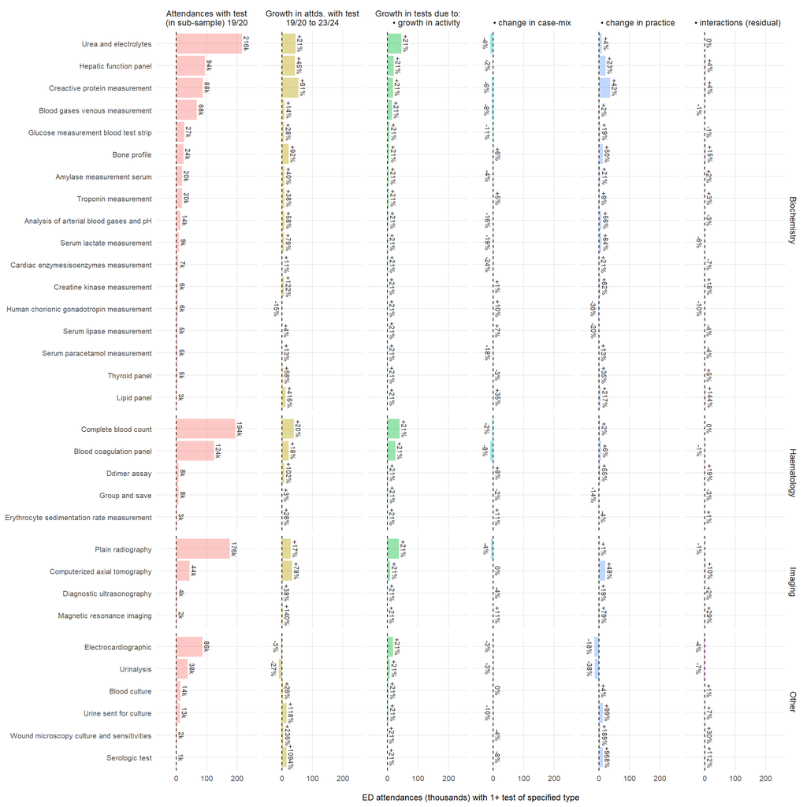

**Absolute changes**

Figure 11: Growth in attendances with 1+ test (19/20 to 23/24), decomposed by factor.

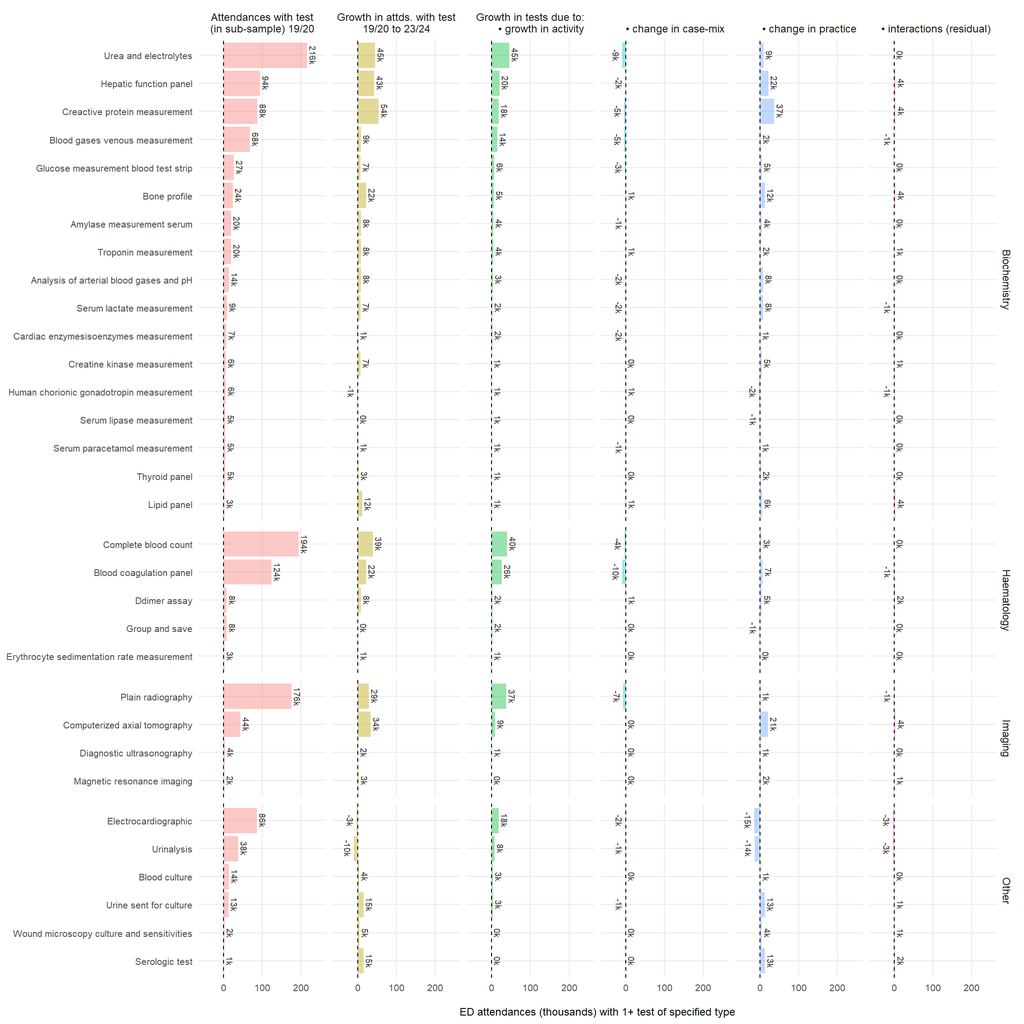

**Table**

Table 8

| Test type | Test category | Attendances with test in 2019/20 (in sub-sample) | Attendances with test in 2023/24 (in sub-sample) | Growth in attendances with test 19/20 to 23/24 | Growth due activity | Growth due casemix | Growth due practice | Growth due interactions |
| --- | --- | --- | --- | --- | --- | --- | --- | --- |
| Urea and electrolytes | Biochemistry | 215,600 | 260,200 | 20.7% | 21% | −4.1% | 4.2% | −0.2% |
| Hepatic function panel | Biochemistry | 94,370 | 137,300 | 45.5% | 21% | −2.0% | 22.9% | 3.8% |
| Creactive protein measurement | Biochemistry | 87,560 | 141,200 | 61.3% | 21% | −5.9% | 41.9% | 4.5% |
| Blood gases venous measurement | Biochemistry | 68,280 | 77,730 | 13.8% | 21% | −7.8% | 2.2% | −1.4% |
| Bone profile | Biochemistry | 23,770 | 45,630 | 91.9% | 21% | 6.1% | 49.7% | 15.3% |
| Glucose measurement blood test strip | Biochemistry | 26,770 | 34,250 | 27.9% | 21% | −10.9% | 18.9% | −0.8% |
| Amylase measurement serum | Biochemistry | 20,020 | 28,110 | 40.4% | 21% | −4.1% | 21.1% | 2.5% |
| Troponin measurement | Biochemistry | 19,930 | 27,560 | 38.3% | 21% | 4.7% | 9.1% | 3.4% |
| Analysis of arterial blood gases and pH | Biochemistry | 14,340 | 22,670 | 58.1% | 21% | −16.3% | 56.2% | −2.7% |
| Serum lactate measurement | Biochemistry | 9,310 | 16,670 | 79.1% | 21% | −19.3% | 83.5% | −6.1% |
| Creatine kinase measurement | Biochemistry | 6,076 | 13,500 | 122.1% | 21% | 0.9% | 82.0% | 18.3% |
| Lipid panel | Biochemistry | 2,938 | 15,150 | 415.8% | 21% | 34.7% | 216.5% | 143.6% |
| Cardiac enzymesisoenzymes measurement | Biochemistry | 7,177 | 7,974 | 11.1% | 21% | −23.9% | 20.7% | −6.7% |
| Thyroid panel | Biochemistry | 4,622 | 7,299 | 57.9% | 21% | −3.4% | 35.1% | 5.2% |
| Serum paracetamol measurement | Biochemistry | 4,962 | 5,604 | 12.9% | 21% | −17.6% | 13.3% | −3.7% |
| Human chorionic gonadotropin measurement | Biochemistry | 5,680 | 4,816 | −15.2% | 21% | 10.1% | −36.4% | −9.9% |
| Serum lipase measurement | Biochemistry | 5,034 | 5,219 | 3.7% | 21% | 6.9% | −19.9% | −4.4% |
| Complete blood count | Haematology | 193,800 | 232,700 | 20.0% | 21% | −2.1% | 1.5% | −0.2% |
| Blood coagulation panel | Haematology | 124,100 | 146,400 | 17.9% | 21% | −7.9% | 5.9% | −1.0% |
| Ddimer assay | Haematology | 8,266 | 16,740 | 102.5% | 21% | 8.1% | 54.8% | 18.6% |
| Group and save | Haematology | 7,591 | 7,813 | 2.9% | 21% | −1.5% | −13.6% | −2.9% |
| Erythrocyte sedimentation rate measurement | Haematology | 2,551 | 3,273 | 28.3% | 21% | 11.1% | −4.4% | 0.8% |
| Plain radiography | Imaging | 175,700 | 204,800 | 16.6% | 21% | −4.2% | 0.7% | −0.8% |
| Computerized axial tomography | Imaging | 43,840 | 78,220 | 78.4% | 21% | −0.3% | 48.1% | 9.8% |
| Diagnostic ultrasonography | Imaging | 4,190 | 5,772 | 37.8% | 21% | −4.4% | 19.2% | 2.1% |
| Magnetic resonance imaging | Imaging | 2,142 | 5,144 | 140.1% | 21% | 11.1% | 78.8% | 29.4% |
| Electrocardiographic | Other | 85,910 | 83,390 | −2.9% | 21% | −2.6% | −17.5% | −3.6% |
| Urinalysis | Other | 38,110 | 27,890 | −26.8% | 21% | −2.7% | −37.8% | −7.2% |
| Urine sent for culture | Other | 12,620 | 27,500 | 117.9% | 21% | −9.7% | 99.4% | 7.2% |
| Blood culture | Other | 13,910 | 17,460 | 25.5% | 21% | −0.5% | 4.2% | 0.8% |
| Serologic test | Other | 1,338 | 15,980 | 1,094.0% | 21% | −7.6% | 968.2% | 112.4% |
| Wound microscopy culture and sensitivities | Other | 2,063 | 6,931 | 236.0% | 21% | −3.6% | 188.5% | 30.3% |

# Appendix 3

Exploratory graphics supporting A3.

**Tests per attendance**

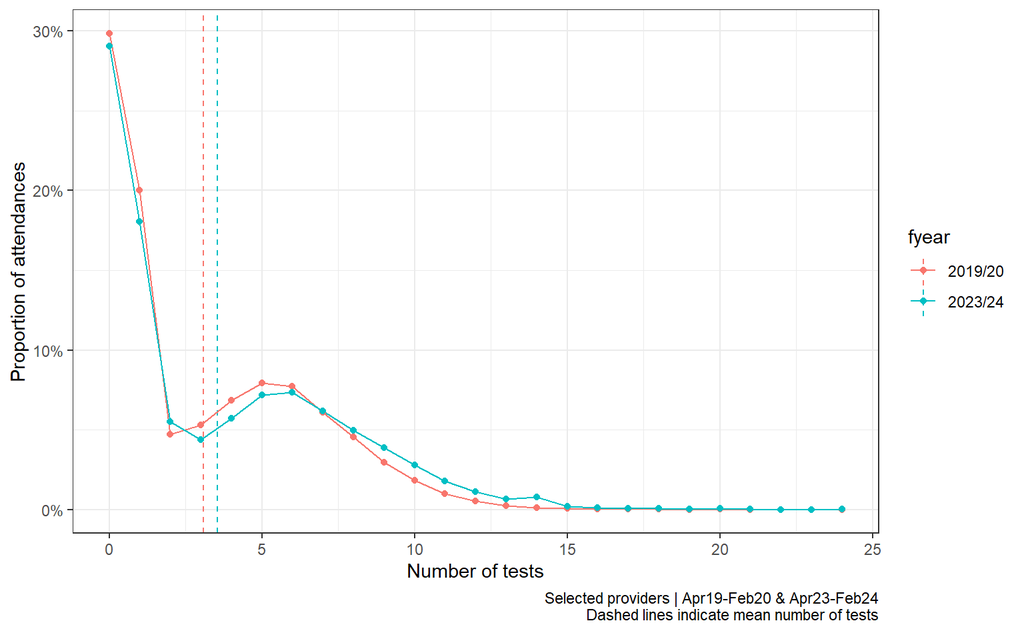

## Tests per attendance (grouped)

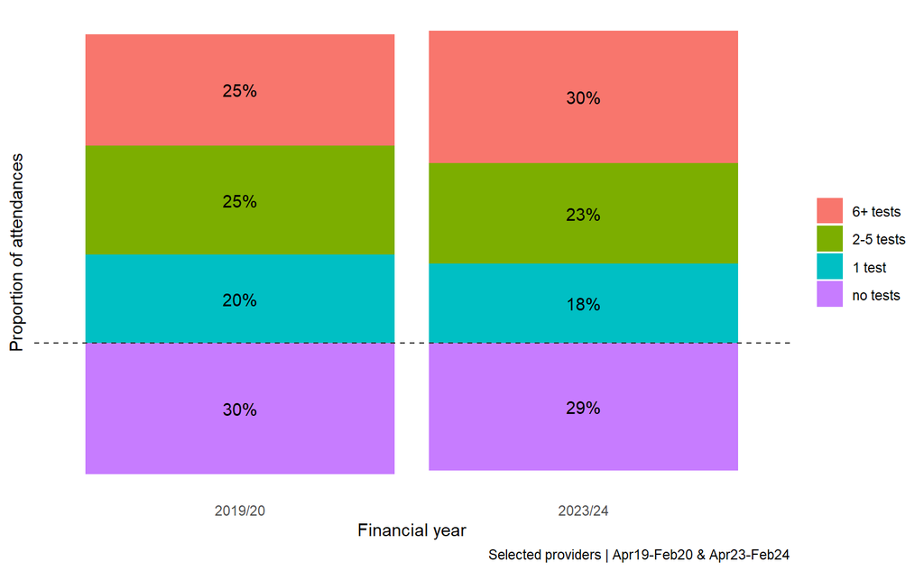

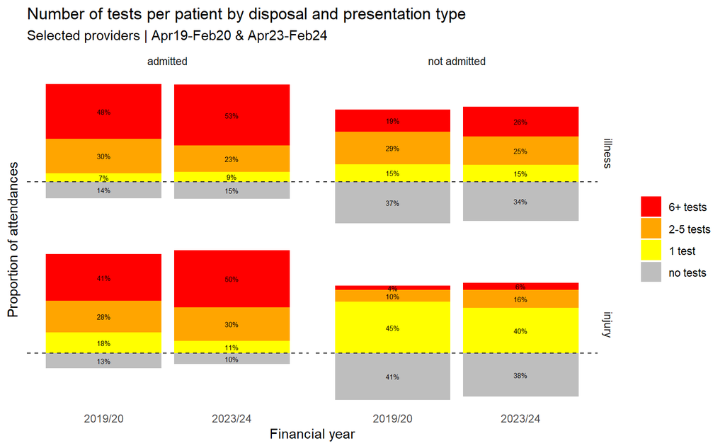

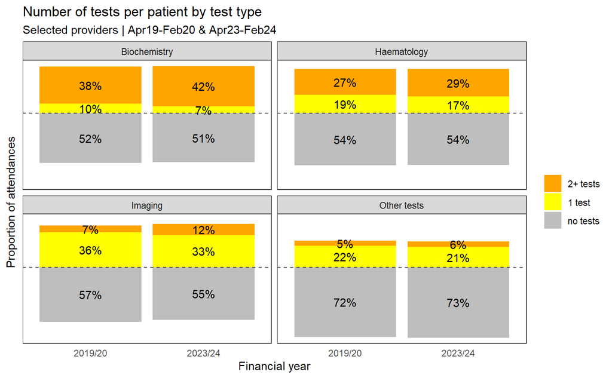

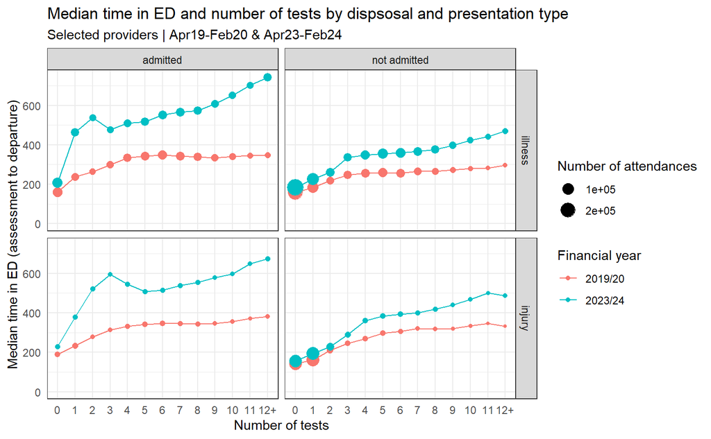

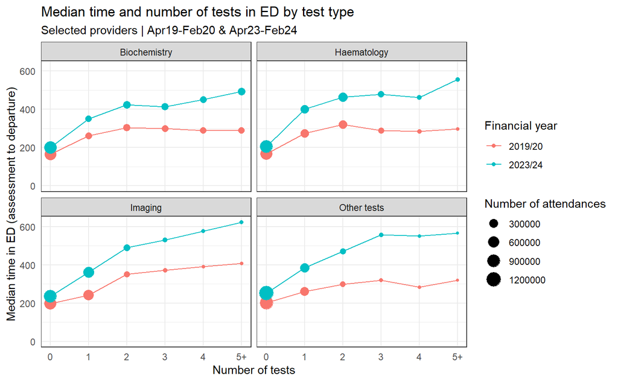